# Symptoms - ‘NativeScript Task Dispatcher’ - IEEE TMC

Carlos Granell, Miguel Matey, Alberto González, Sven Casteleyn - [SyMptOMS team](http://geotec.uji.es/projects/SyMptOMS/), [GEOTEC research group](http://geotec.uji.es/)

19/2/2021 (updated 22 febrero, 2021)

This document analyses the self-developed scheduler component in Android-based mobile devices as part of the [SyMptOMS project](http://geotec.uji.es/projects/SyMptOMS/). This sofware component tested here is called [NativeScript Task Dispatcher](https://www.npmjs.com/package/nativescript-task-dispatcher), that’s a [NativeScript](https://nativescript.org/) plugin aimed to ease mobile app’s tasks definition and the execution of task workflows in background, regardless of whether the app is visible to the user or not. [NativeScript Task Dispatcher](https://www.npmjs.com/package/nativescript-task-dispatcher) is publicy available as open source software.

Required libraries and runtime environment description are as follows.

```r
library(tidyverse)
library(kableExtra)
library(here)
library(lubridate)
library(stringr)
library(scales)
library(grid)
library(gridBase)
library(gridExtra)
```

# Data preparation

Raw data files are cleaned and merged together into a single file stored in the folder `data`. New fields such as dates breakdown are computed too.

Here, we reuse the data files generated in April/May 2020, whose file names start with the prefix `BA_`.

# Analysis

**Key Variables**:

## Experiment 1

### Missingness of data

But, *A1 with Ad-hoc* and *NV with Ad-hoc* did **not** end the experiment. The expected number of executions are

- A1: 2.0264^{4} instead of 1.0896^{4}.
- NV: 2.0264^{4} instead of 3551.

Missingness of data scans per device and scheduler.

| ID | Scheduler | OS | # planned executions | # real executions | % missingness |
| --- | --- | --- | --- | --- | --- |
| A1 | Ad-hoc | 9.0 | 20264 | 10832 | 46.55% |
| A1 | NativeScript | 9.0 | 21007 | 20926 | 0.39% |
| BQ | Ad-hoc | 8.1 | 20264 | 20146 | 0.58% |
| BQ | NativeScript | 8.1 | 21008 | 20891 | 0.56% |
| H9 | Ad-hoc | 9.0 | 21662 | 21574 | 0.41% |
| H9 | NativeScript | 9.0 | 20172 | 20008 | 0.81% |
| NV | Ad-hoc | 7.0 | 20264 | 3528 | 82.59% |
| NV | NativeScript | 7.0 | 21008 | 20748 | 1.24% |

### Performance

We discard 77 out of 138653 observations whose abs(delay) >= 10 seconds.

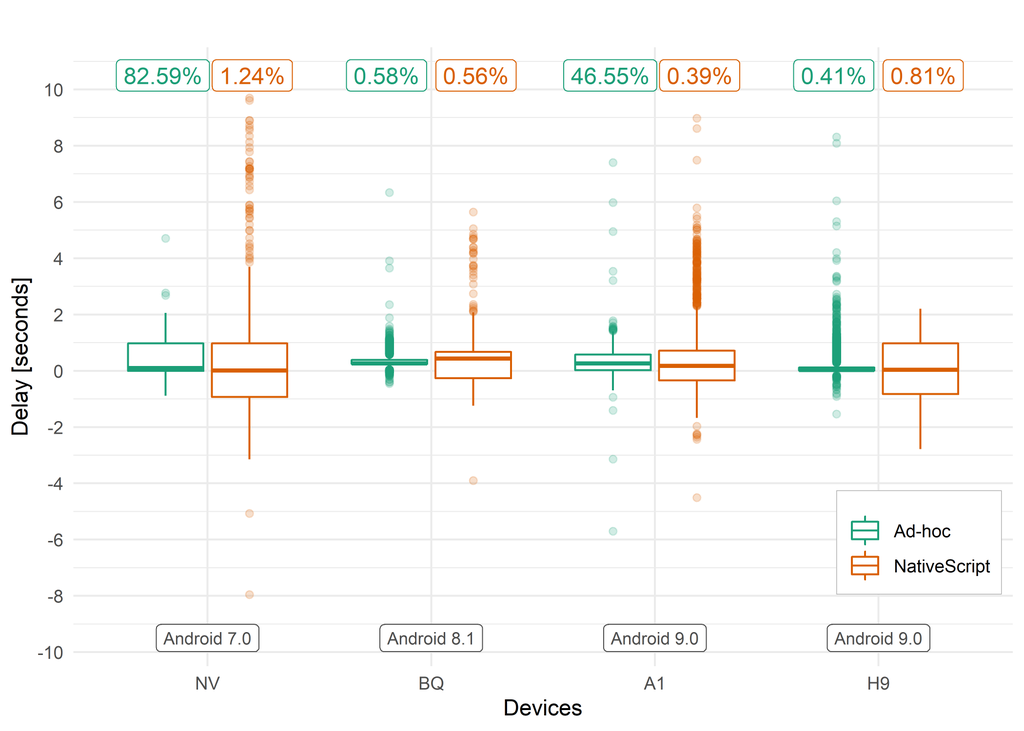

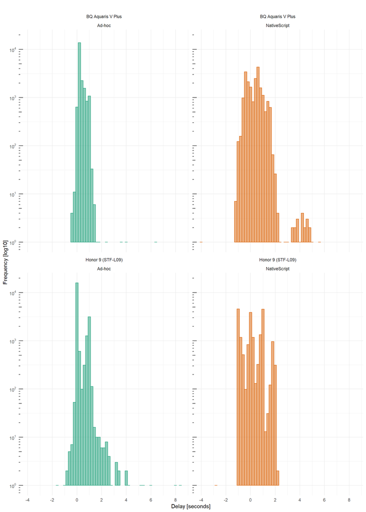